# project analysis autos

```python
import numpy as np
import pandas as pd
import matplotlib.pyplot as plt
import seaborn as sns
import scipy.stats as ss
```

```python
data=pd.read_csv(r"C:\Users\Intel\Downloads\autos.csv",sep=",",encoding="latin-1")
```

```python
data
```

|  | dateCrawled | name | seller | offerType | price | abtest | vehicleType | yearOfRegistration | gearbox | powerPS | model | kilometer | monthOfRegistration | fuelType | brand | notRepairedDamage | dateCreated | nrOfPictures | postalCode | lastSeen |
| --- | --- | --- | --- | --- | --- | --- | --- | --- | --- | --- | --- | --- | --- | --- | --- | --- | --- | --- | --- | --- |
| 0 | 2016-03-24 11:52:17 | Golf_3_1.6 | privat | Angebot | 480 | test | NaN | 1993 | manuell | 0 | golf | 150000 | 0 | benzin | volkswagen | NaN | 2016-03-24 00:00:00 | 0 | 70435 | 2016-04-07 03:16:57 |
| 1 | 2016-03-24 10:58:45 | A5_Sportback_2.7_Tdi | privat | Angebot | 18300 | test | coupe | 2011 | manuell | 190 | NaN | 125000 | 5 | diesel | audi | ja | 2016-03-24 00:00:00 | 0 | 66954 | 2016-04-07 01:46:50 |
| 2 | 2016-03-14 12:52:21 | Jeep_Grand_Cherokee_"Overland" | privat | Angebot | 9800 | test | suv | 2004 | automatik | 163 | grand | 125000 | 8 | diesel | jeep | NaN | 2016-03-14 00:00:00 | 0 | 90480 | 2016-04-05 12:47:46 |
| 3 | 2016-03-17 16:54:04 | GOLF_4_1_4__3TÜRER | privat | Angebot | 1500 | test | kleinwagen | 2001 | manuell | 75 | golf | 150000 | 6 | benzin | volkswagen | nein | 2016-03-17 00:00:00 | 0 | 91074 | 2016-03-17 17:40:17 |
| 4 | 2016-03-31 17:25:20 | Skoda_Fabia_1.4_TDI_PD_Classic | privat | Angebot | 3600 | test | kleinwagen | 2008 | manuell | 69 | fabia | 90000 | 7 | diesel | skoda | nein | 2016-03-31 00:00:00 | 0 | 60437 | 2016-04-06 10:17:21 |
| ... | ... | ... | ... | ... | ... | ... | ... | ... | ... | ... | ... | ... | ... | ... | ... | ... | ... | ... | ... | ... |
| 371523 | 2016-03-14 17:48:27 | Suche_t4___vito_ab_6_sitze | privat | Angebot | 2200 | test | NaN | 2005 | NaN | 0 | NaN | 20000 | 1 | NaN | sonstige_autos | NaN | 2016-03-14 00:00:00 | 0 | 39576 | 2016-04-06 00:46:52 |
| 371524 | 2016-03-05 19:56:21 | Smart_smart_leistungssteigerung_100ps | privat | Angebot | 1199 | test | cabrio | 2000 | automatik | 101 | fortwo | 125000 | 3 | benzin | smart | nein | 2016-03-05 00:00:00 | 0 | 26135 | 2016-03-11 18:17:12 |
| 371525 | 2016-03-19 18:57:12 | Volkswagen_Multivan_T4_TDI_7DC_UY2 | privat | Angebot | 9200 | test | bus | 1996 | manuell | 102 | transporter | 150000 | 3 | diesel | volkswagen | nein | 2016-03-19 00:00:00 | 0 | 87439 | 2016-04-07 07:15:26 |
| 371526 | 2016-03-20 19:41:08 | VW_Golf_Kombi_1_9l_TDI | privat | Angebot | 3400 | test | kombi | 2002 | manuell | 100 | golf | 150000 | 6 | diesel | volkswagen | NaN | 2016-03-20 00:00:00 | 0 | 40764 | 2016-03-24 12:45:21 |
| 371527 | 2016-03-07 19:39:19 | BMW_M135i_vollausgestattet_NP_52.720____Euro | privat | Angebot | 28990 | control | limousine | 2013 | manuell | 320 | m_reihe | 50000 | 8 | benzin | bmw | nein | 2016-03-07 00:00:00 | 0 | 73326 | 2016-03-22 03:17:10 |

371528 rows × 20 columns

# Analysis 1

# 1) Perform general Data analysis

```python
data.info()
```

```
<class 'pandas.core.frame.DataFrame'>
RangeIndex: 371528 entries, 0 to 371527
Data columns (total 20 columns):
 #   Column               Non-Null Count   Dtype
---  ------               --------------   -----
 0   dateCrawled          371528 non-null  object
 1   name                 371528 non-null  object
 2   seller               371528 non-null  object
 3   offerType            371528 non-null  object
 4   price                371528 non-null  int64
 5   abtest               371528 non-null  object
 6   vehicleType          333659 non-null  object
 7   yearOfRegistration   371528 non-null  int64
 8   gearbox              351319 non-null  object
 9   powerPS              371528 non-null  int64
 10  model                351044 non-null  object
 11  kilometer            371528 non-null  int64
 12  monthOfRegistration  371528 non-null  int64
 13  fuelType             338142 non-null  object
 14  brand                371528 non-null  object
 15  notRepairedDamage    299468 non-null  object
 16  dateCreated          371528 non-null  object
 17  nrOfPictures         371528 non-null  int64
 18  postalCode           371528 non-null  int64
 19  lastSeen             371528 non-null  object
dtypes: int64(7), object(13)
memory usage: 56.7+ MB
```

```python
data.describe()
```

|  | price | yearOfRegistration | powerPS | kilometer | monthOfRegistration | nrOfPictures | postalCode |
| --- | --- | --- | --- | --- | --- | --- | --- |
| count | 3.715280e+05 | 371528.000000 | 371528.000000 | 371528.000000 | 371528.000000 | 371528.0 | 371528.00000 |
| mean | 1.729514e+04 | 2004.577997 | 115.549477 | 125618.688228 | 5.734445 | 0.0 | 50820.66764 |
| std | 3.587954e+06 | 92.866598 | 192.139578 | 40112.337051 | 3.712412 | 0.0 | 25799.08247 |
| min | 0.000000e+00 | 1000.000000 | 0.000000 | 5000.000000 | 0.000000 | 0.0 | 1067.00000 |
| 25% | 1.150000e+03 | 1999.000000 | 70.000000 | 125000.000000 | 3.000000 | 0.0 | 30459.00000 |
| 50% | 2.950000e+03 | 2003.000000 | 105.000000 | 150000.000000 | 6.000000 | 0.0 | 49610.00000 |
| 75% | 7.200000e+03 | 2008.000000 | 150.000000 | 150000.000000 | 9.000000 | 0.0 | 71546.00000 |
| max | 2.147484e+09 | 9999.000000 | 20000.000000 | 150000.000000 | 12.000000 | 0.0 | 99998.00000 |

```python
d1=data.copy()
```

```python
d1=d1.drop_duplicates()
```

```python
d1.duplicated().sum()
```

```
0
```

```python
d1=d1.fillna("Not mentioned")
```

```python
d1.info()
```

```
<class 'pandas.core.frame.DataFrame'>
Int64Index: 371524 entries, 0 to 371527
Data columns (total 20 columns):
 #   Column               Non-Null Count   Dtype
---  ------               --------------   -----
 0   dateCrawled          371524 non-null  object
 1   name                 371524 non-null  object
 2   seller               371524 non-null  object
 3   offerType            371524 non-null  object
 4   price                371524 non-null  int64
 5   abtest               371524 non-null  object
 6   vehicleType          371524 non-null  object
 7   yearOfRegistration   371524 non-null  int64
 8   gearbox              371524 non-null  object
 9   powerPS              371524 non-null  int64
 10  model                371524 non-null  object
 11  kilometer            371524 non-null  int64
 12  monthOfRegistration  371524 non-null  int64
 13  fuelType             371524 non-null  object
 14  brand                371524 non-null  object
 15  notRepairedDamage    371524 non-null  object
 16  dateCreated          371524 non-null  object
 17  nrOfPictures         371524 non-null  int64
 18  postalCode           371524 non-null  int64
 19  lastSeen             371524 non-null  object
dtypes: int64(7), object(13)
memory usage: 59.5+ MB
```

```python
d1.describe()
```

|  | price | yearOfRegistration | powerPS | kilometer | monthOfRegistration | nrOfPictures | postalCode |
| --- | --- | --- | --- | --- | --- | --- | --- |
| count | 3.715240e+05 | 371524.000000 | 371524.000000 | 371524.000000 | 371524.000000 | 371524.0 | 371524.00000 |
| mean | 1.729530e+04 | 2004.578033 | 115.549039 | 125618.842928 | 5.734451 | 0.0 | 50820.49427 |
| std | 3.587973e+06 | 92.867097 | 192.140488 | 40112.138811 | 3.712423 | 0.0 | 25799.08841 |
| min | 0.000000e+00 | 1000.000000 | 0.000000 | 5000.000000 | 0.000000 | 0.0 | 1067.00000 |
| 25% | 1.150000e+03 | 1999.000000 | 70.000000 | 125000.000000 | 3.000000 | 0.0 | 30459.00000 |
| 50% | 2.950000e+03 | 2003.000000 | 105.000000 | 150000.000000 | 6.000000 | 0.0 | 49610.00000 |
| 75% | 7.200000e+03 | 2008.000000 | 150.000000 | 150000.000000 | 9.000000 | 0.0 | 71546.00000 |
| max | 2.147484e+09 | 9999.000000 | 20000.000000 | 150000.000000 | 12.000000 | 0.0 | 99998.00000 |

# 2)Can you tell me the Distribution of Vehicles based on Year of Registration with the help of a plot

```python
pd.crosstab(index=d1["vehicleType"], columns=d1.loc[(d1["yearOfRegistration"]<=2023), "yearOfRegistration"])
```

| yearOfRegistration vehicleType | 1000 | 1001 | 1039 | 1111 | 1200 | 1234 | 1253 | 1255 | 1300 | 1400 | ... | 2010 | 2011 | 2012 | 2013 | 2014 | 2015 | 2016 | 2017 | 2018 | 2019 |
| --- | --- | --- | --- | --- | --- | --- | --- | --- | --- | --- | --- | --- | --- | --- | --- | --- | --- | --- | --- | --- | --- |
| Not mentioned | 38 | 1 | 1 | 4 | 1 | 4 | 1 | 1 | 2 | 1 | ... | 174 | 167 | 92 | 87 | 76 | 218 | 9438 | 10530 | 3989 | 27 |
| andere | 0 | 0 | 0 | 0 | 0 | 0 | 0 | 0 | 0 | 0 | ... | 83 | 58 | 59 | 38 | 31 | 14 | 16 | 1 | 0 | 0 |
| bus | 0 | 0 | 0 | 0 | 0 | 0 | 0 | 0 | 0 | 0 | ... | 1230 | 1377 | 1061 | 654 | 455 | 297 | 37 | 2 | 0 | 0 |
| cabrio | 0 | 0 | 0 | 0 | 0 | 0 | 0 | 0 | 0 | 0 | ... | 797 | 724 | 628 | 423 | 239 | 144 | 28 | 1 | 0 | 0 |
| coupe | 0 | 0 | 0 | 0 | 0 | 0 | 0 | 0 | 0 | 0 | ... | 838 | 684 | 463 | 312 | 234 | 175 | 65 | 2 | 1 | 0 |
| kleinwagen | 0 | 0 | 0 | 0 | 0 | 0 | 0 | 0 | 0 | 0 | ... | 2375 | 2147 | 2159 | 1361 | 981 | 534 | 106 | 2 | 2 | 0 |
| kombi | 0 | 0 | 0 | 0 | 0 | 0 | 0 | 0 | 0 | 0 | ... | 2657 | 2817 | 1804 | 1057 | 828 | 425 | 35 | 4 | 0 | 0 |
| limousine | 0 | 0 | 0 | 0 | 0 | 0 | 0 | 0 | 0 | 0 | ... | 3345 | 3103 | 2239 | 1572 | 1367 | 765 | 72 | 3 | 1 | 0 |
| suv | 0 | 0 | 0 | 0 | 0 | 0 | 0 | 0 | 0 | 0 | ... | 855 | 991 | 913 | 653 | 591 | 410 | 62 | 1 | 0 | 0 |

9 rows × 115 columns

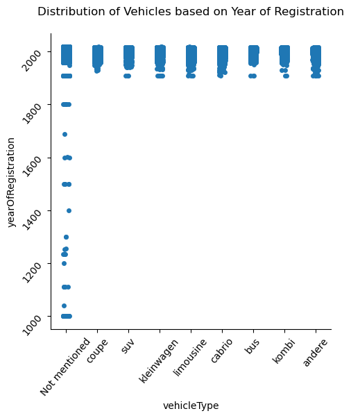

```python
sns.catplot(x=d1["vehicleType"], y=d1.loc[(d1["yearOfRegistration"]<=2023), "yearOfRegistration"])
plt.title("Distribution of Vehicles based on Year of Registration\n")
plt.xticks(rotation=50)
plt.yticks(rotation=50)
plt.show()
```

# 3) Create a plot based on the Variation of the price range by the vehicle type

```python
p=pd.pivot_table(d1, index="vehicleType", values="price", aggfunc="mean")
p
```

| vehicleType | price |
| --- | --- |
| Not mentioned | 20137.725263 |
| andere | 677328.957700 |
| bus | 10302.742956 |
| cabrio | 15066.444013 |
| coupe | 25964.071214 |
| kleinwagen | 5694.287796 |
| kombi | 7741.302399 |
| limousine | 11116.186404 |
| suv | 13242.822397 |

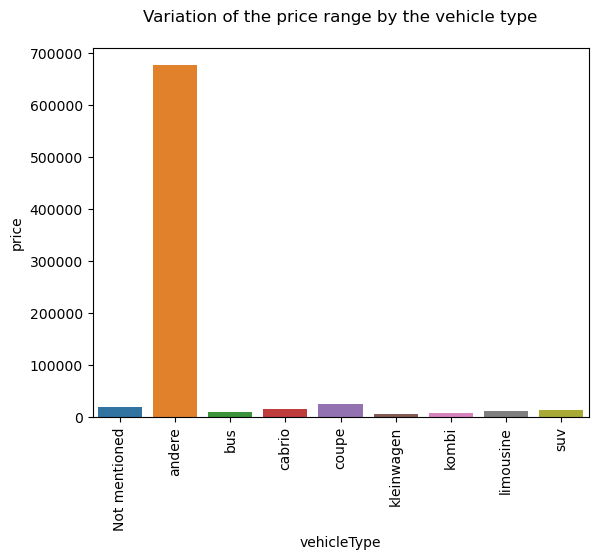

```python
sns.barplot(p,x=p.index, y="price")
plt.title("Variation of the price range by the vehicle type\n")
plt.xticks(rotation=90)
plt.show()
```

# 4) Find out Total count of vehicles by type available on ebay for sale.As well as create a visualization for the client

```python
d1["vehicleType"].value_counts()
```

```
limousine        95894
kleinwagen       80022
kombi            67563
Not mentioned    37869
bus              30201
cabrio           22898
coupe            19013
suv              14707
andere            3357
Name: vehicleType, dtype: int64
```

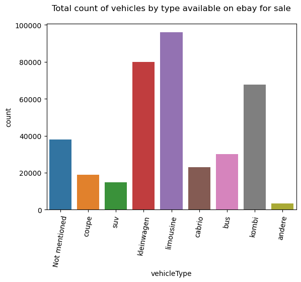

```python
sns.countplot(d1, x="vehicleType")
plt.title("Total count of vehicles by type available on ebay for sale\n")
plt.xticks(rotation=80)
plt.show()
```

# 5) Is there any relationship between dollar_price and kilometer? 1

```python
d1[["price", "kilometer"]].corr(method="pearson")
```

|  | price | kilometer |
| --- | --- | --- |
| price | 1.000000 | -0.000635 |
| kilometer | -0.000635 | 1.000000 |

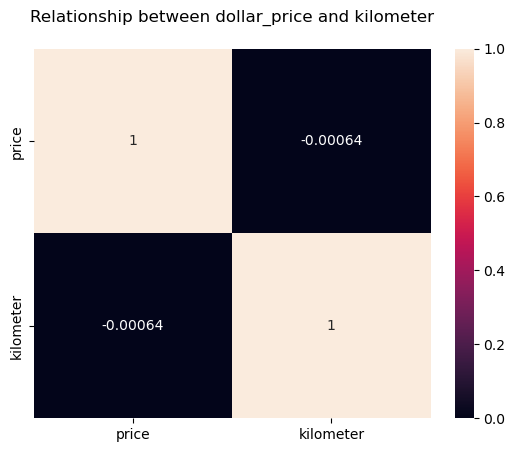

```python
sns.heatmap(d1[["price", "kilometer"]].corr(method="pearson"), annot=True)
plt.title("Relationship between dollar_price and kilometer\n")
plt.show()
```

# Analysis 2

### 1) Can you tell me No of Vehicles by Brand Available on ebay for sale with the help of visualization

```python
x=d1['brand'].value_counts()
```

```python
x
```

```
volkswagen        79639
bmw               40274
opel              40136
mercedes_benz     35307
audi              32873
ford              25573
renault           17969
peugeot           11027
fiat               9676
seat               7022
mazda              5695
skoda              5641
smart              5249
citroen            5182
nissan             5037
toyota             4694
sonstige_autos     3982
hyundai            3646
mini               3394
volvo              3327
mitsubishi         3061
honda              2836
kia                2555
alfa_romeo         2345
suzuki             2327
porsche            2215
chevrolet          1845
chrysler           1452
dacia               900
jeep                807
daihatsu            806
subaru              779
land_rover          770
jaguar              621
trabant             591
daewoo              542
saab                530
rover               490
lancia              484
lada                225
Name: brand, dtype: int64
```

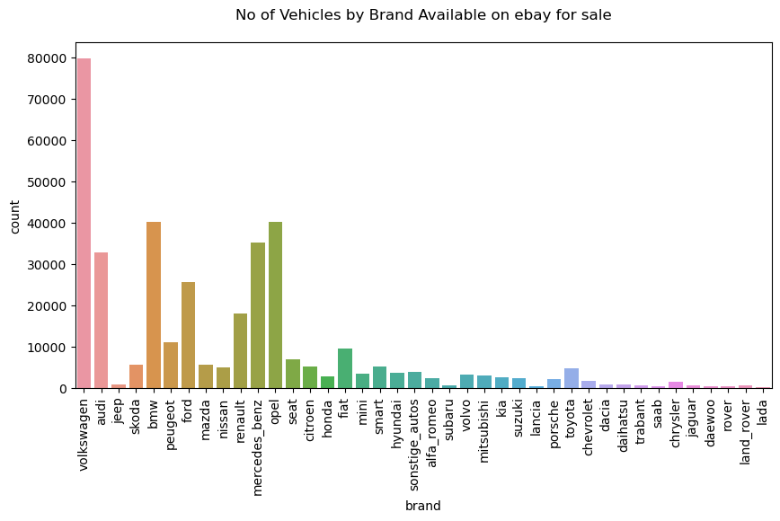

```python
plt.figure(figsize=(10,5))
sns.countplot(d1, x="brand")
plt.title("No of Vehicles by Brand Available on ebay for sale\n")
plt.xticks(rotation=90)
plt.show()
```

### 2) What is the Average price for vehicles based on the type of vehicle as well as on the type of gearbox.Explain me with both numerical and visualization analysis

```python
p=pd.pivot_table(d1,index="vehicleType", columns="gearbox", values="price", aggfunc="mean")
```

```python
p
```

| gearbox vehicleType | Not mentioned | automatik | manuell |
| --- | --- | --- | --- |
| Not mentioned | 52208.845834 | 7600.924596 | 8639.161862 |
| andere | 3661.203252 | 7366.861496 | 825539.352000 |
| bus | 124897.289820 | 10599.265713 | 6321.168265 |
| cabrio | 9751.342246 | 16254.374208 | 14897.823880 |
| coupe | 233553.441558 | 35510.948175 | 12400.255031 |
| kleinwagen | 33104.509510 | 3889.552200 | 4606.803784 |
| kombi | 3445.444699 | 8910.045892 | 7464.741491 |
| limousine | 3904.749183 | 19004.102243 | 8505.151711 |
| suv | 7270.198276 | 16764.091774 | 10040.553599 |

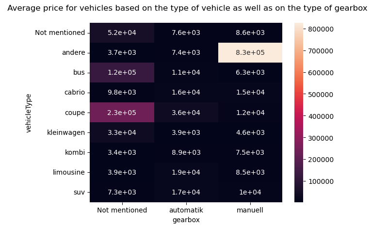

```python
sns.heatmap(p, annot=True)
plt.title(" Average price for vehicles based on the type of vehicle as well as on the type of gearbox\n")
plt.show()
```